# Weight Lifting Exercise Classifier

Kay Dee

Friday, January 23, 2015

### About the data

Using devices such as Jawbone Up, Nike FuelBand, and Fitbit it is now possible to collect a large amount of data about personal activity relatively inexpensively. These type of devices are part of the quantified self movement – a group of enthusiasts who take measurements about themselves regularly to improve their health, to find patterns in their behavior, or because they are tech geeks. One thing that people regularly do is quantify how much of a particular activity they do, but they rarely quantify how well they do it. In this project, data is taken from accelerometers on the belt, forearm, arm, and dumbell of 6 participants. They were asked to **perform barbell lifts correctly and incorrectly in 5 different ways**. More information is available from the website here: `http://groupware.les.inf.puc-rio.br/har#weight_lifting_exercises`

### Objective

The goal of this project is to predict the manner in which the subjects did the exercise. This is the **classe** variable in the training set.

### Actions performed in broad strokes

1. Read in the datasets
2. Prune unnecessary features
3. Explore the data
4. Visually inspect the extracted dataset
5. Fit the model(s)
6. Evaluate the fitted the model(s)
7. Visualize the prediction
8. Select the final model

### Exploring the data

Total cases of exercise types against for each subject is given in table below

```r
table(num.train$classe, num.train$user_name)
```

```
##
##     adelmo carlitos charles eurico jeremy pedro
##   A   1165      834     899    865   1177   640
##   B    776      690     745    592    489   505
##   C    750      493     539    489    652   499
##   D    515      486     642    582    522   469
##   E    686      609     711    542    562   497
```

**Summary statistics for the extracted feature**

```
##                              0%        25%        50%        75%      100%
## roll_belt              -28.9000    1.10000  113.00000  123.00000  162.0000
## pitch_belt             -55.8000    1.76000    5.28000   14.90000   60.3000
## yaw_belt              -180.0000  -88.30000  -13.00000   12.90000  179.0000
## total_accel_belt         0.0000    3.00000   17.00000   18.00000   29.0000
## gyros_belt_x            -1.0400   -0.03000    0.03000    0.11000    2.2200
## gyros_belt_y            -0.6400    0.00000    0.02000    0.11000    0.6400
## gyros_belt_z            -1.4600   -0.20000   -0.10000   -0.02000    1.6200
## accel_belt_x          -120.0000  -21.00000  -15.00000   -5.00000   85.0000
## accel_belt_y           -69.0000    3.00000   35.00000   61.00000  164.0000
## accel_belt_z          -275.0000 -162.00000 -152.00000   27.00000  105.0000
## magnet_belt_x          -52.0000    9.00000   35.00000   59.00000  485.0000
## magnet_belt_y          354.0000  581.00000  601.00000  610.00000  673.0000
## magnet_belt_z         -623.0000 -375.00000 -320.00000 -306.00000  293.0000
## roll_arm              -180.0000  -31.77500    0.00000   77.30000  180.0000
## pitch_arm              -88.8000  -25.90000    0.00000   11.20000   88.5000
## yaw_arm               -180.0000  -43.10000    0.00000   45.87500  180.0000
## total_accel_arm          1.0000   17.00000   27.00000   33.00000   66.0000
## gyros_arm_x             -6.3700   -1.33000    0.08000    1.57000    4.8700
## gyros_arm_y             -3.4400   -0.80000   -0.24000    0.14000    2.8400
## gyros_arm_z             -2.3300   -0.07000    0.23000    0.72000    3.0200
## accel_arm_x           -404.0000 -242.00000  -44.00000   84.00000  437.0000
## accel_arm_y           -318.0000  -54.00000   14.00000  139.00000  308.0000
## accel_arm_z           -636.0000 -143.00000  -47.00000   23.00000  292.0000
## magnet_arm_x          -584.0000 -300.00000  289.00000  637.00000  782.0000
## magnet_arm_y          -392.0000   -9.00000  202.00000  323.00000  583.0000
## magnet_arm_z          -597.0000  131.25000  444.00000  545.00000  694.0000
## roll_dumbbell         -153.7137  -18.49342   48.17424   67.61401  153.5456
## pitch_dumbbell        -149.5936  -40.88688  -20.95772   17.49923  149.4024
## yaw_dumbbell          -150.8712  -77.64421   -3.32377   79.64285  154.9523
## total_accel_dumbbell     0.0000    4.00000   10.00000   19.00000   58.0000
## gyros_dumbbell_x      -204.0000   -0.03000    0.13000    0.35000    2.2200
## gyros_dumbbell_y        -2.1000   -0.14000    0.03000    0.21000   52.0000
## gyros_dumbbell_z        -2.3800   -0.31000   -0.13000    0.03000  317.0000
## accel_dumbbell_x      -419.0000  -50.00000   -8.00000   11.00000  235.0000
## accel_dumbbell_y      -189.0000   -8.00000   41.50000  111.00000  315.0000
## accel_dumbbell_z      -334.0000 -142.00000   -1.00000   38.00000  318.0000
## magnet_dumbbell_x     -643.0000 -535.00000 -479.00000 -304.00000  592.0000
## magnet_dumbbell_y    -3600.0000  231.00000  311.00000  390.00000  633.0000
## magnet_dumbbell_z     -262.0000  -45.00000   13.00000   95.00000  452.0000
## roll_forearm          -180.0000   -0.73750   21.70000  140.00000  180.0000
## pitch_forearm          -72.5000    0.00000    9.24000   28.40000   89.8000
## yaw_forearm           -180.0000  -68.60000    0.00000  110.00000  180.0000
## total_accel_forearm      0.0000   29.00000   36.00000   41.00000  108.0000
## gyros_forearm_x        -22.0000   -0.22000    0.05000    0.56000    3.9700
## gyros_forearm_y         -7.0200   -1.46000    0.03000    1.62000  311.0000
## gyros_forearm_z         -8.0900   -0.18000    0.08000    0.49000  231.0000
## accel_forearm_x       -498.0000 -178.00000  -57.00000   76.00000  477.0000
## accel_forearm_y       -632.0000   57.00000  201.00000  312.00000  923.0000
## accel_forearm_z       -446.0000 -182.00000  -39.00000   26.00000  291.0000
## magnet_forearm_x     -1280.0000 -616.00000 -378.00000  -73.00000  672.0000
## magnet_forearm_y      -896.0000    2.00000  591.00000  737.00000 1480.0000
## magnet_forearm_z      -973.0000  191.00000  511.00000  653.00000 1090.0000
```

**Distribution of each feature, limiting the y-axis to ignore the minimum outlier**

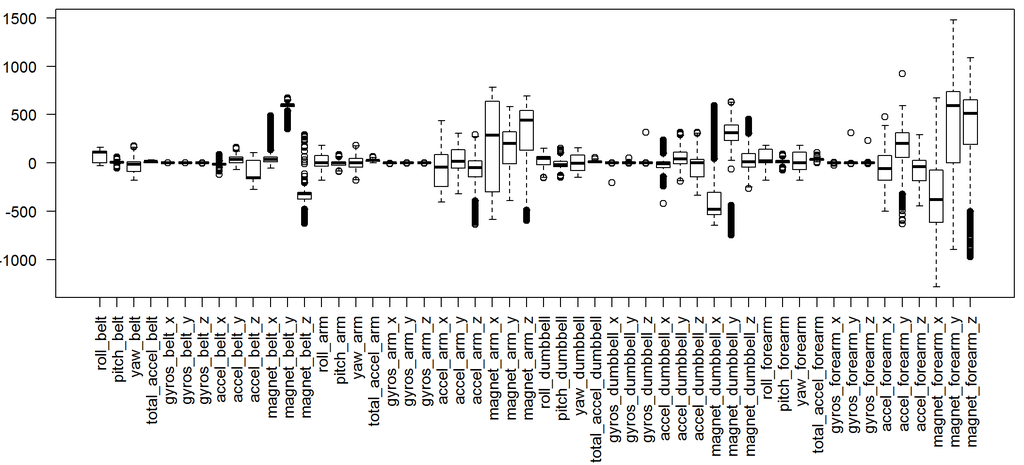

**Snapshot of 4 feature spread:**

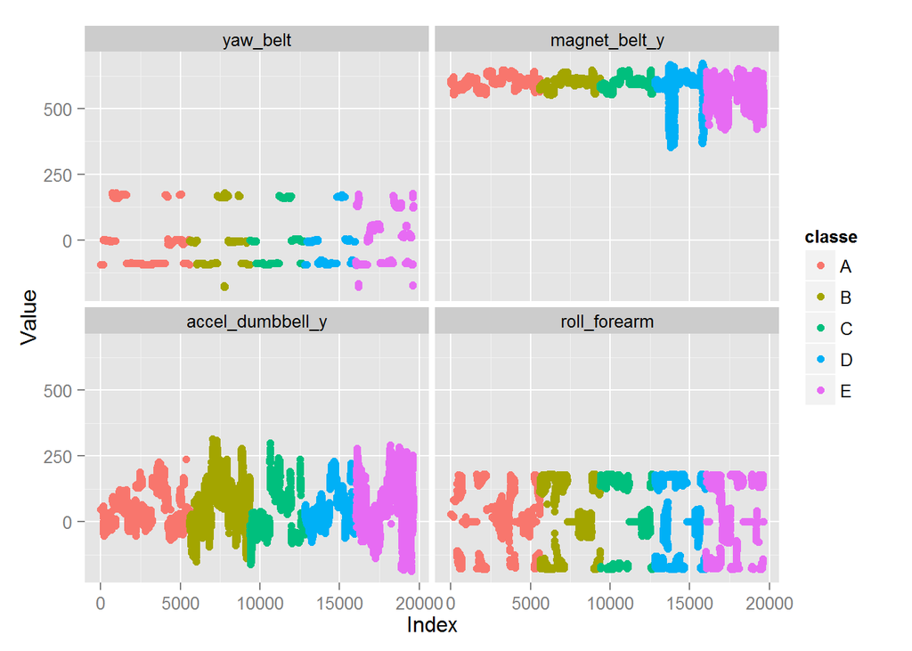

### Model the data

For the current dataset, we face a **Classification** problem. We started with a dataset of 160 feature set and having 19622 samples. Cursory glance gave us that 1st variable is an index, followed by subject identifier. These were excluded from the training dataset.

Then 3 variables were timestamps, we decided to ignore those. Next 2 variables were some windowing indicator. We decide to drop those 2 also.

**Final pruned training dataset had 52 numeric features and 1 factor variable. The factor variable is the predicate variable.**

We first tried a `Linear Discriminant` model, with 10 fold cross validation. This gave 73% Accuracy on the training set.

Next we tried a `Random Forest` classifier, with setting out-of-bag tries to 4. The final random forest selected had `number of variable per level` set to 2 and had Accuracy of 99.6%.

Because of higher accuracy we selected the final `Random Forest` as our classifier. This model gave 100% matching (accepted) prediction on the test dataset.

We also ran `SVM` and `RDA` on the training dataset, but they fared similar to the `LDA` model.

### Summary of the final model

**Model accuracy and tuning parameters**

```
##    Accuracy     Kappa mtry
## 1 0.9959739 0.9949073    2
## 2 0.9956681 0.9945204   27
## 3 0.9908266 0.9883953   52
```

So the best tuning is done for the **number of variable per level (mtry) =** 2

**Importance of the top 20 features in the fitted random forest:**

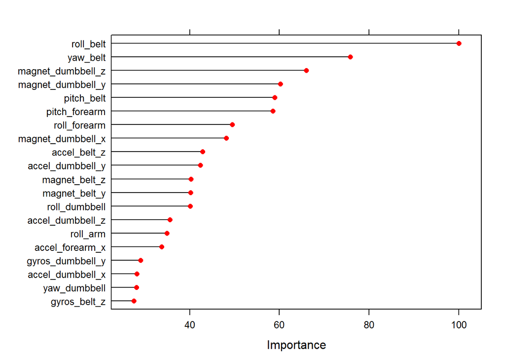